# R Notebook

```r
JAVA_HOME<- "C:/Software/JRE/JAVA/bin"
library(tm)
library(wordcloud)
library(RColorBrewer)
library(dplyr)
library(tidytext)
library(topicmodels)
library(slam)
library(igraph)
library(rvest)
library(tibble)
library(qdap)
library(sentimentr)
library(gplots)
library(syuzhet)
library(factoextra)
library(beeswarm)
library(scales)
library(RANN)
library(tidyr)
library(ggplot2)

source("../lib/plotstacked.R")
source("../lib/speechFuncs.R")

# read data
folder.path="../data/InauguralSpeeches/"
speeches=list.files(path = folder.path, pattern = "*.txt")
prez.out=substr(speeches, 6, nchar(speeches)-4)

length.speeches=rep(NA, length(speeches))
ff.all<-Corpus(DirSource(folder.path))

ff.all<-tm_map(ff.all, stripWhitespace)
ff.all<-tm_map(ff.all, content_transformer(tolower))
ff.all<-tm_map(ff.all, removeWords, stopwords("english"))
ff.all<-tm_map(ff.all, removeWords, character(0))
ff.all<-tm_map(ff.all, removePunctuation)
tdm.all<-TermDocumentMatrix(ff.all)
tdm.tidy=tidy(tdm.all)
tdm.overall=summarise(group_by(tdm.tidy, term), sum(count))

dtm <- DocumentTermMatrix(ff.all,
                          control = list(weighting =
                                           function(x)
                                             weightTfIdf(x, normalize =
                                                           FALSE),
                                         stopwords = TRUE))
ff.dtm=tidy(dtm)
```

# Part 1

I am interested in the quality of speeches of each president because it may somehow reflect the person’s writing ability, speaking ability and intelligence quotient. Thus, we evaluate the quality of their speech from several aspects including number of advanced vocabulary used, the number of long sentences, the average number of words in a sentence. Since inaugural speeches are more formal, we only concentrate on inaugural speeches in the following study.

1. GRE is a required test to become a master student, thus GRE vocabulary is not so verbal and it would be hard to memorize the speech if it contains many GRE words. The more words in the speech, the harder for the president to remember and it could indicates the higher ability the president has.

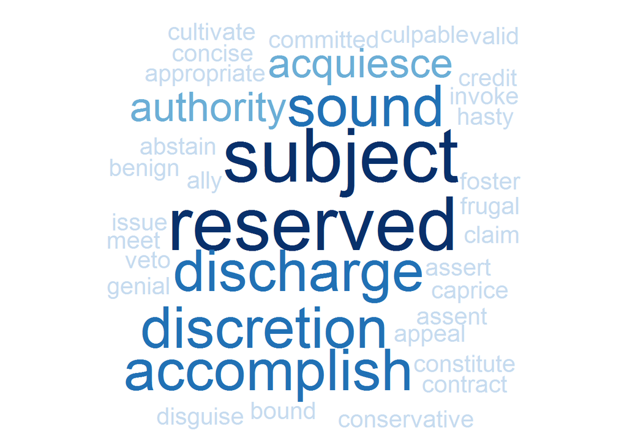

```r
# get GRE vocabulary list
d<- read.table("../data/gre.txt", header = T)
d<- unlist(d)
d<- as.character(d)

# create the document term matrix based on GRE vocabulary
dtm2<- DocumentTermMatrix(ff.all,list(dictionary=d))
ff.dtm2<-tidy(dtm2)

# choose a wordcloud randomly
i<- sample(length(speeches),size = 1)
  wordcloud(ff.dtm2$term[ff.dtm2$document==speeches[i]],
            ff.dtm2$count[ff.dtm2$document==speeches[i]],
              scale=c(5,0.5),
              max.words=200,
              min.freq=1,
              random.order=FALSE,
              rot.per=0,
              use.r.layout=FALSE,
              random.color=FALSE,
              colors=brewer.pal(9,"Blues"),
            main=prez.out[i])
```

```r
# calculate the sum of GRE words in each inaugural speech
count<- tapply(ff.dtm2$count, ff.dtm2$document ,sum)

shorten<- function(rn) {
  new_rn<- substr(rn, start=6, stop=nchar(rn)-6)
  return(new_rn)
}
new_rn <- sapply(speeches,shorten)

# some presidents made more than one inaugural speech, thus, calculate the average words
count_mean<- tapply(count, new_rn, mean)

GREwords<- data.frame(presidentnames= names(count_mean),GREword= count_mean, rank=rank(count_mean, ties.method = "min"))
```

who are the top 5?

```r
GREwords[order(GREwords$GREword, decreasing = T),][1:5,]
```

```
##                            presidentnames GREword rank
## WilliamHenryHarrison WilliamHenryHarrison     191   40
## MartinvanBuren             MartinvanBuren      96   39
## FranklinPierce             FranklinPierce      95   38
## JamesKPolk                     JamesKPolk      92   37
## WarrenGHarding             WarrenGHarding      83   36
```

who are the last 5?

```r
GREwords[order(GREwords$GREword),][1:5,]
```

```
##                        presidentnames GREword rank
## TheodoreRoosevelt   TheodoreRoosevelt    10.0    1
## LyndonBJohnson         LyndonBJohnson    16.0    2
## DonaldJTrump             DonaldJTrump    20.0    3
## FranklinDRoosevelt FranklinDRoosevelt    20.5    4
## GeorgeWashington     GeorgeWashington    21.5    5
```

2. In addition, the number of long sentences in a speech can also indicate the intellectual level of a person. But how long is “a long sentence”? First, we should calculate the number of words in every sentence.

```r
sentence.list=NULL
for(i in 1:nrow(speech.list)){
  sentences=sent_detect(speech.list$fulltext[i],
                        endmarks = c("?", ".", "!", "|",";"))
  if(length(sentences)>0){
    emotions=get_nrc_sentiment(sentences)
    word.count=word_count(sentences)
    # colnames(emotions)=paste0("emo.", colnames(emotions))
    # in case the word counts are zeros?
    emotions=diag(1/(word.count+0.01))%*%as.matrix(emotions)
    sentence.list=rbind(sentence.list,
                        cbind(speech.list[i,-ncol(speech.list)],
                              sentences=as.character(sentences),
                              word.count,
                              emotions,
                              sent.id=1:length(sentences)
                              )
    )
  }
}
```

Some non-sentences exist in raw data due to erroneous extra end-of sentence marks.

```r
sentence.list=
  sentence.list%>%
  filter(!is.na(word.count))
```

#### First term

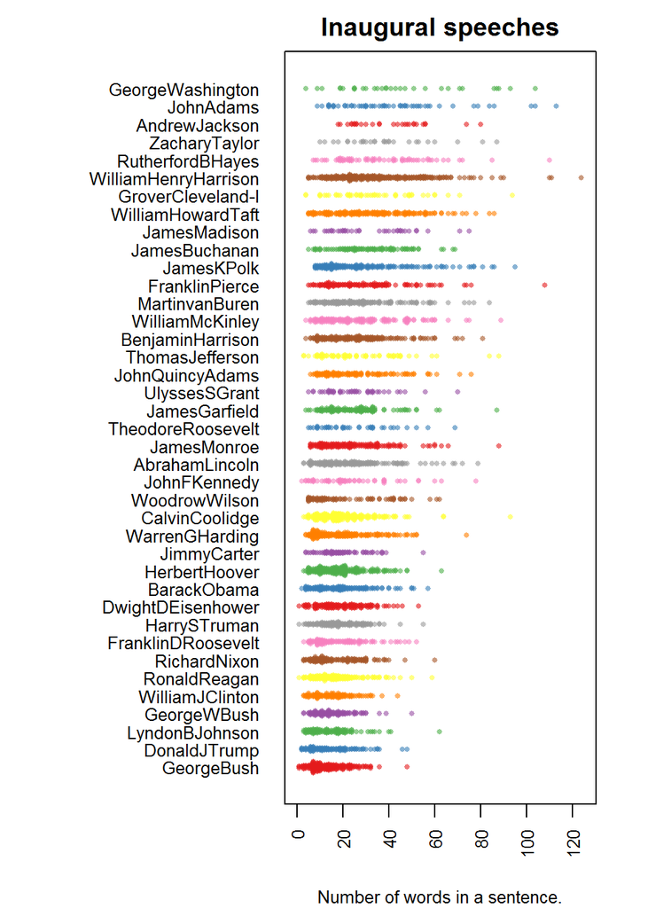

```r
par(mar=c(4, 11, 2, 2))

sentence.list.sel=filter(sentence.list, type=="inaug", Term==1)
sentence.list.sel$File=factor(sentence.list.sel$File)
sentence.list.sel$FileOrdered=reorder(sentence.list.sel$File,
                                  sentence.list.sel$word.count,
                                  mean,
                                  order=T)

beeswarm(word.count~FileOrdered,
         data=sentence.list.sel,
         horizontal = TRUE,
         pch=16, col=alpha(brewer.pal(9, "Set1"), 0.6),
         cex=0.55, cex.axis=0.8, cex.lab=0.8,
         spacing=5/nlevels(sentence.list.sel$FileOrdered),
         las=2, xlab="Number of words in a sentence.", ylab="",
         main="Inaugural speeches")
```

#### Second term

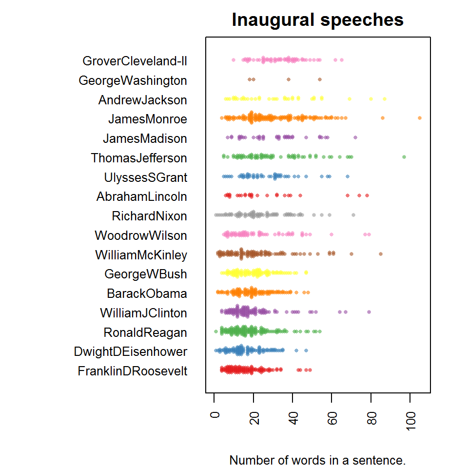

```r
par(mar=c(4, 11, 2, 2))

#sel.comparison=levels(sentence.list$FileOrdered)
sentence.list.sel=filter(sentence.list, type=="inaug", Term==2)
sentence.list.sel$File=factor(sentence.list.sel$File)
sentence.list.sel$FileOrdered=reorder(sentence.list.sel$File,
                                  sentence.list.sel$word.count,
                                  mean,
                                  order=T)

beeswarm(word.count~FileOrdered,
         data=sentence.list.sel,
         horizontal = TRUE,
         pch=16, col=alpha(brewer.pal(9, "Set1"), 0.6),
         cex=0.55, cex.axis=0.8, cex.lab=0.8,
         spacing=5/nlevels(sentence.list.sel$FileOrdered),
         las=2, xlab="Number of words in a sentence.", ylab="",
         main="Inaugural speeches")
```

We can see from the plot that number of words in a sentence are mostly less than 60, thus we regard the sentence has more than 60 words as a long sentence, and calculate the number of long sentences in a speech.

```r
presidentnames<- names(count_mean)
long_sentence<-data.frame(presidentnames, "number"=Inf)

for (i in 1:length(presidentnames)) {
  a<- sentence.list%>%
        filter(File==presidentnames[i],
             type=="inaug",
             Term==1,
             word.count>=60)%>%
      select(sentences)
  long_sentence[i,2]<- nrow(a)
}

long_sentence$rank2<- rank(long_sentence$number, ties.method = "min")
# Let's see the top 5 president
long_sentence[order(long_sentence$number,decreasing = T),][1:5,]
```

```
##          presidentnames number rank2
## 35 WilliamHenryHarrison     25    40
## 19           JamesKPolk     15    39
## 36    WilliamHowardTaft     12    38
## 11     GeorgeWashington      9    36
## 23            JohnAdams      9    36
```

```r
# And the last 5
long_sentence[order(long_sentence$number),][1:5,]
```

```
##        presidentnames number rank2
## 3         BarackObama      0     1
## 6        DonaldJTrump      0     1
## 7   DwightDEisenhower      0     1
## 8  FranklinDRoosevelt      0     1
## 10         GeorgeBush      0     1
```

3. Moreover, the average and deviation of length of the sentences can also represent the level and stability of a person’s “intelligence”.

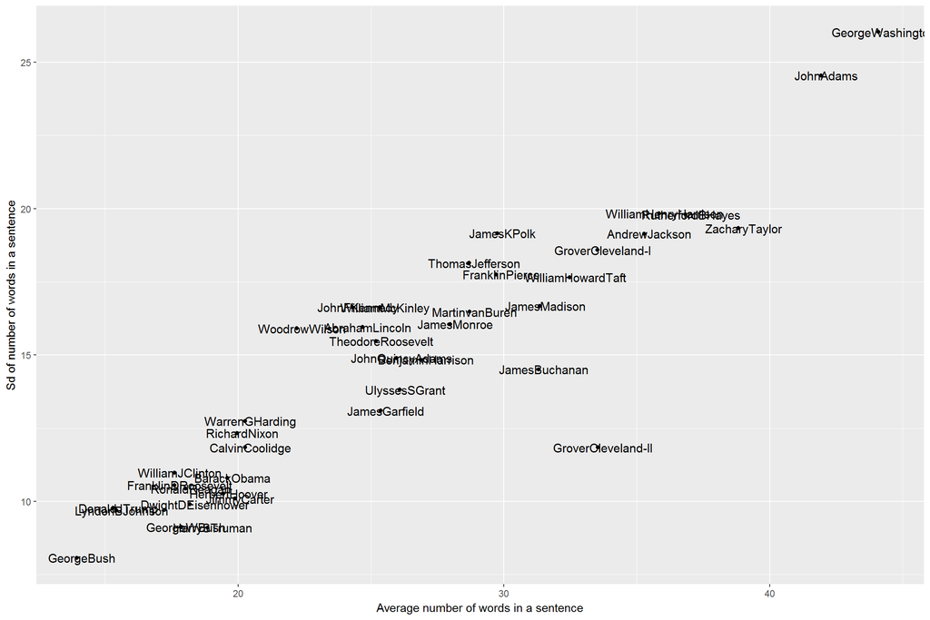

```r
sentence.list.sel=filter(sentence.list, type=="inaug")
word_count_mean<- tapply(sentence.list.sel$word.count, sentence.list.sel$File, mean)
word_count_sd<- tapply(sentence.list.sel$word.count,sentence.list.sel$File, sd)

wordbind<- data.frame(word_count_mean,word_count_sd)

g<- ggplot(data = wordbind) +
    geom_point(mapping = aes(x=word_count_mean,y=word_count_sd)) +
    geom_text(mapping = aes(word_count_mean+0.2, word_count_sd, label=rownames(wordbind)),cex=4)+
    labs(x = "Average number of words in a sentence", y = "Sd of number of words in a sentence")
g
```

```r
png("../output/wordcount.png",width=1500, height=800)
  g
  dev.off()
```

Thus, we get three seperate rank of the presidents based on different standard, then we combined these together and reach a final rank of the inaugural speeches.

```r
average_words<- data.frame(presidentnames=names(word_count_mean),words= word_count_mean, rank3=rank(word_count_mean, ties.method = "min"))

total_rank<- merge(GREwords, long_sentence, merge="presidentnames")
total_rank<- merge(total_rank, average_words)
total_rank$finalrank <- rowMeans(cbind(total_rank$rank,total_rank$rank2,total_rank$rank3))

total_rank<- total_rank[order(total_rank$finalrank,decreasing = T),]
```

who are the top 5?

```r
total_rank[1:5,]
```

```
##          presidentnames GREword rank number rank2    words rank3 finalrank
## 35 WilliamHenryHarrison     191   40     25    40 35.83830    36  38.66667
## 19           JamesKPolk      92   37     15    39 29.75776    29  35.00000
## 23            JohnAdams      63   28      9    36 41.92727    39  34.33333
## 36    WilliamHowardTaft      75   32     12    38 32.47904    32  34.00000
## 9        FranklinPierce      95   38      7    34 29.70536    28  33.33333
```

who are the last 5?

```r
total_rank[36:40,]
```

```
##        presidentnames GREword rank number rank2    words rank3 finalrank
## 10         GeorgeBush    36.0   15      0     1 13.92771     1  5.666667
## 26     LyndonBJohnson    16.0    2      1    12 15.42268     3  5.666667
## 37    WilliamJClinton    29.5   11      0     1 17.60563     5  5.666667
## 8  FranklinDRoosevelt    20.5    4      0     1 17.60317     4  3.000000
## 6        DonaldJTrump    20.0    3      0     1 15.29474     2  2.000000
```

```r
sentence.list.trump=filter(sentence.list, President=="Donald J. Trump")
sentence.list.trump<-sentence.list.trump[order(sentence.list.trump$Words),]
sentence.list.trump$File=factor(sentence.list.trump$File)

table(sentence.list.trump$Words,sentence.list.trump$type)
```

```
##
##        inaug nomin speeches
##   1433    95     0        0
##   2330     0     0      141
##   5092     0   346        0
##   6188     0     0      505
##   6777     0     0      585
```

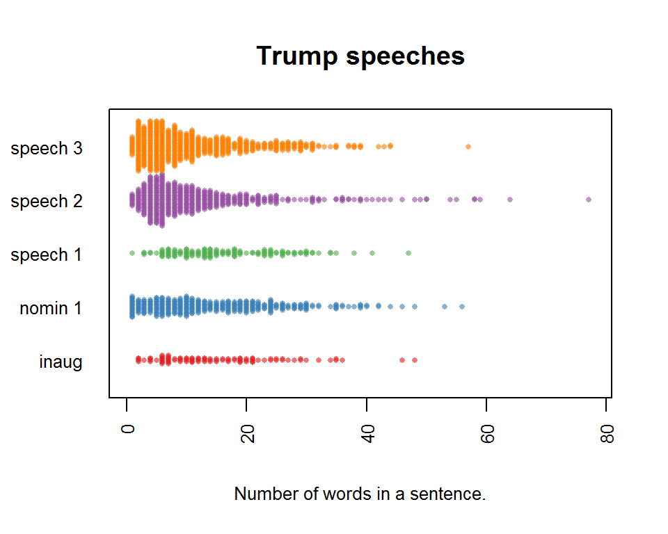

```r
sentence.list.trump$FileOrdered=rep(c("inaug","speech 1","nomin 1","speech 2","speech 3"),c(95,141,346,505,585))

beeswarm(word.count~FileOrdered,
         data=sentence.list.trump,
         horizontal = TRUE,
         pch=16, col=alpha(brewer.pal(9, "Set1"), 0.6),
         cex=0.55, cex.axis=0.8, cex.lab=0.8, spacing=1/5,
         las=2, xlab="Number of words in a sentence.", ylab="",
         main="Trump speeches")
```

```r
# The plot shows Trump uses mostsly 3-20 words in a sentences. And I would like to know what the most number of words in a sentence Trump used.
table(sentence.list.trump$word.count)
```

```
##
##   1   2   3   4   5   6   7   8   9  10  11  12  13  14  15  16  17  18
##  47  79  80 103 104 121  87  88  72  77  77  57  54  49  48  41  41  32
##  19  20  21  22  23  24  25  26  27  28  29  30  31  32  33  34  35  36
##  43  36  30  26  23  32  26  22  17  16  19  17  16   9   2   5  13   7
##  37  38  39  40  41  42  43  44  46  47  48  49  50  53  54  55  56  57
##   5   6  10   3   2   4   2   4   3   1   3   1   2   1   1   1   1   1
##  58  59  64  77
##   2   1   1   1
```

```r
# The table tells us the 6-word-sentence is the most, and what are these sentences?
sentence.list.trump%>%
    filter(word.count==6)%>%
  select(sentences)%>%sample_n(10)
```

```
##                                        sentences
## 11    7 billion dollars in cash ransom payments.
## 73                I'm going to have the meeting.
## 42                  I don't think he'll need it.
## 108               It is a two-way street, right?
## 44                       I'd do a very good job.
## 21  Instead, my opponent wants Sanctuary Cities.
## 58                      So that's the way it is.
## 98       And don't forget your Second Amendment.
## 110                  She is going to do nothing.
## 97                     And then we get them out.
```

```r
# I would also like to know what is the longest sentences.
sentence.list.trump%>%
    filter(word.count==77)%>%
  select(sentences)
```

```
##                                                                                                                                                                                                                                                                                                          …
## 1 So if you want to move to another country and if you want to fire all of our great American workers that got you there in the first place, you can move from Michigan to Tennessee and to North Carolina and South Carolina, you can move from South Carolina back to Michigan, you can do anywhere, yo…
```

Let’s make a contrast to the long sentences in President George Washington’s speeches.

```r
sentence.list%>%
   filter(File=="GeorgeWashington",
           word.count>=100)%>%
   select(sentences)
```

```
##                                                                                                                                                                                                                                                                                                          …
## 1                                                       Such being the impressions under which I have, in obedience to the public summons, repaired to the present station, it would be peculiarly improper to omit in this first official act my fervent supplications to that Almighty Being who rules …
## 2 While, then, every part of our country thus feels an immediate and particular interest in union, all the parts combined can not fail to find in the united mass of means and efforts greater strength, greater resource, proportionably greater security from external danger, a less frequent interrup…
```

and I also want to have a look at the long sentences in our champion, William Henry Harrison’s speeches.

```r
sentence.list%>%
    filter(File=="WilliamHenryHarrison",
           word.count>=115)%>%
  select(sentences)
```

```
##                                                                                                                                                                                                                                                                                                          …
## 1 I assure them, therefore, that it is my intention to use every means in my power to preserve the friendly intercourse which now so happily subsists with every foreign nation, and that although, of course, not well informed as to the state of pending negotiations with any of them, I see in the p…
```

# Part 2

cluster

```r
# choose suitable n, reduce the terms to about 50
n<- 0.3
dtm_cluster <- removeSparseTerms(dtm, n)
dtm_cluster
```

```
## <<DocumentTermMatrix (documents: 58, terms: 55)>>
## Non-/sparse entries: 2585/605
## Sparsity           : 19%
## Maximal term length: 10
## Weighting          : term frequency - inverse document frequency (tf-idf)
```

```r
tdm_cluster <- as.TermDocumentMatrix(dtm_cluster)
tdm_cluster <- weightTfIdf(tdm_cluster)
```

```r
# convert the sparse term-document matrix to a standard data frame
mydata_cluster <- as.data.frame(inspect(tdm_cluster))
mydata_cluster <- scale(mydata_cluster)
d <- dist(mydata_cluster, method = "euclidean") # distance matrix
fit <- hclust(d, method="ward.D")
```

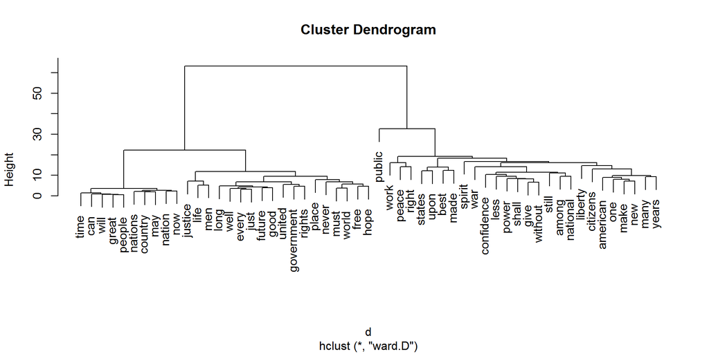

```r
# display dendogram
plot(fit)
```

```r
# save the dendogram
png(paste("../output/", "WordCluster.png", sep = ''),
    width=10, height=10,
    units="in", res=700)
plot(fit)
dev.off()
```

# Part 3

topic modeling

```r
dtm_topic<- DocumentTermMatrix(ff.all)

# set topic number=10
k = 10
SEED <- 2003

# use four different method to do topic modeling
ff.all_TM2 <- list(
  VEM = LDA(dtm_topic, k = k, control = list(seed = SEED)),
  VEM_fixed = LDA(dtm_topic, k = k, control = list(estimate.alpha = FALSE, seed = SEED)),
  Gibbs = LDA(dtm_topic, k = k, method = "Gibbs",
              control = list(seed = SEED, burnin = 1000, thin = 100, iter = 1000)),
  CTM = CTM(dtm_topic, k = k,
            control = list(seed = SEED, var = list(tol = 10^-4), em = list(tol = 10^-3))) )
```

```
## warning: cg didn't converge (lambda)
## warning: cg didn't converge (lambda)
## warning: cg didn't converge (lambda)
```

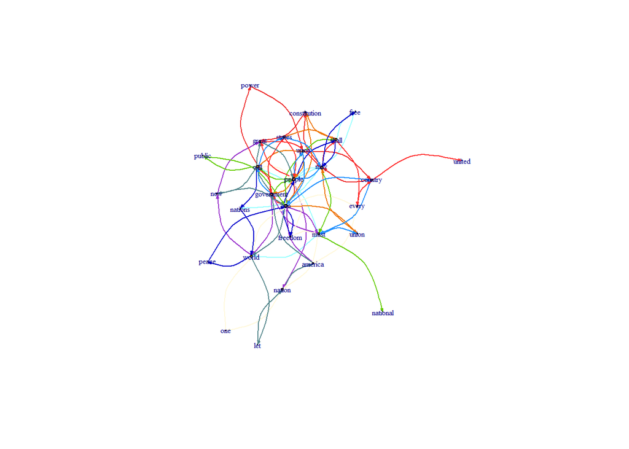

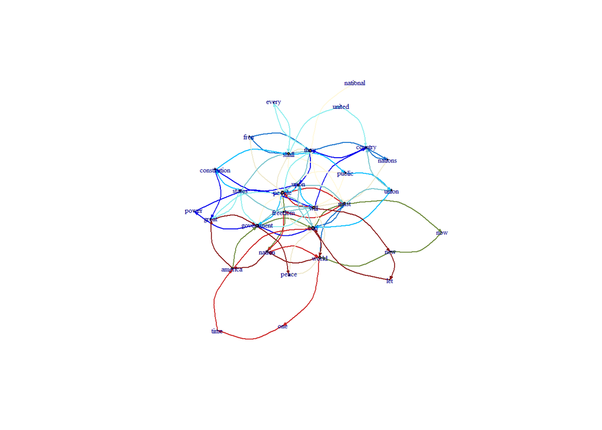

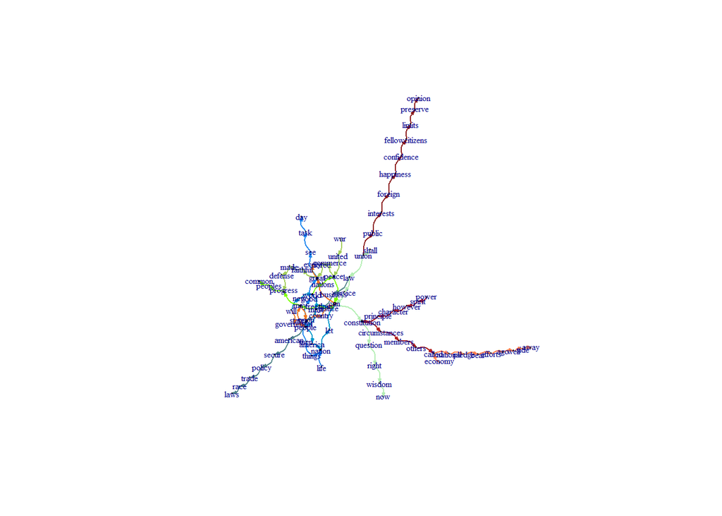

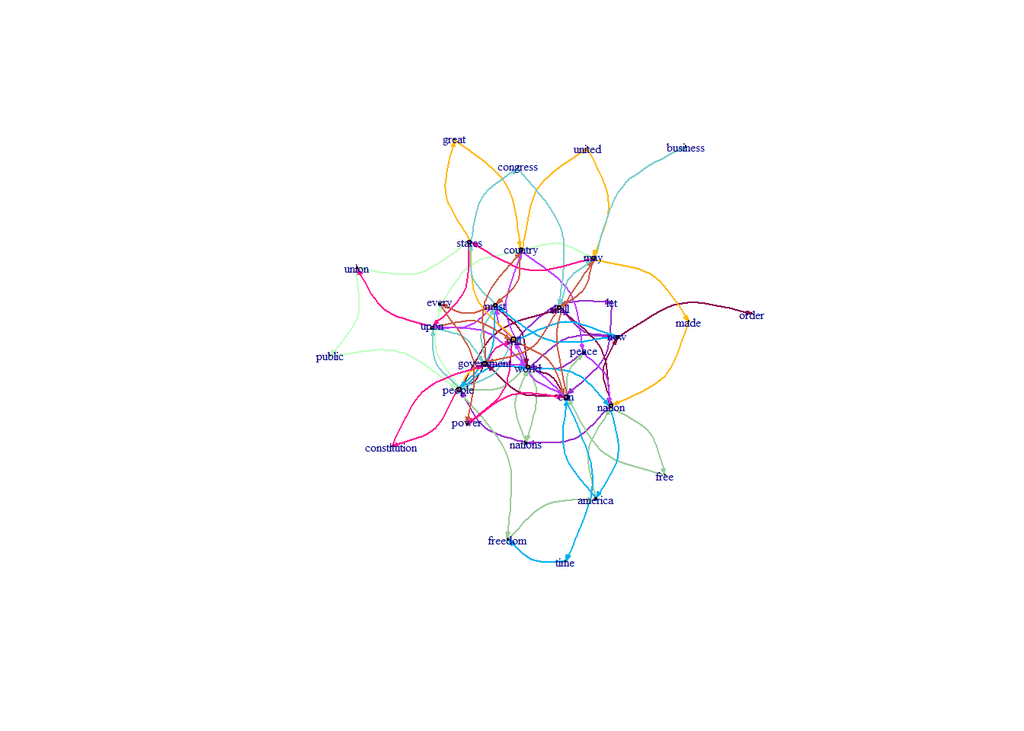

```r
termsForSave1<- terms(ff.all_TM2[["VEM"]], 10)
termsForSave2<- terms(ff.all_TM2[["VEM_fixed"]], 10)
termsForSave3<- terms(ff.all_TM2[["Gibbs"]], 10)
termsForSave4<- terms(ff.all_TM2[["CTM"]], 10)

x<-array(NA,dim = c(10,10,4))
x[,,1]<-termsForSave1
x[,,2]<-termsForSave2
x[,,3]<-termsForSave3
x[,,4]<-termsForSave4

for (n in 1:4) {
  tfs <- as.data.frame(x[, , n], stringsAsFactors = F)
  adjacent_list <- lapply(1:10, function(i) embed(tfs[,i], 2)[, 2:1])
  edgelist = as.data.frame(do.call(rbind, adjacent_list), stringsAsFactors =F)
  g <-graph.data.frame(edgelist,directed=T )
  l<-layout.fruchterman.reingold(g)
  nodesize = centralization.degree(g)$res
  V(g)$size = log( centralization.degree(g)$res )

  nodeLabel = V(g)$name
  E(g)$color =  unlist(lapply(sample(colors()[26:137], 10), function(i) rep(i, 9))); unique(E(g)$color)


# display the topic network plot
plot(g, vertex.label= nodeLabel,  edge.curved=TRUE,
     vertex.label.cex =0.5,  edge.arrow.size=0.2, layout=l )

# save the plot
 png(  paste("../output/topic_graph", n, ".png", sep=""),
    width=5, height=5,
    units="in", res=700)

  plot(g, vertex.label= nodeLabel,  edge.curved=TRUE,
     vertex.label.cex =0.5,  edge.arrow.size=0.2, layout=l )

dev.off()
}
```